# Final Project: t-tests in R

I will be using the built-in dataset, iris, for my following examples. This data set contains sepal length, sepal width, petal length, and petal width measurements for 3 different species of iris (50 each) for a total of 150 observations.

```r
head(iris)
```

```
##   Sepal.Length Sepal.Width Petal.Length Petal.Width Species
## 1          5.1         3.5          1.4         0.2  setosa
## 2          4.9         3.0          1.4         0.2  setosa
## 3          4.7         3.2          1.3         0.2  setosa
## 4          4.6         3.1          1.5         0.2  setosa
## 5          5.0         3.6          1.4         0.2  setosa
## 6          5.4         3.9          1.7         0.4  setosa
```

## Two-sample *t*-tests

### Example 1: Setosa vs Versicolor

For my examples, I am going to assume the 3 assumptions for a t-test. Just to double check that Sepal Width data looks approximately normal, I plotted a histogram. It looks normal so I will continue on with the t-tests.

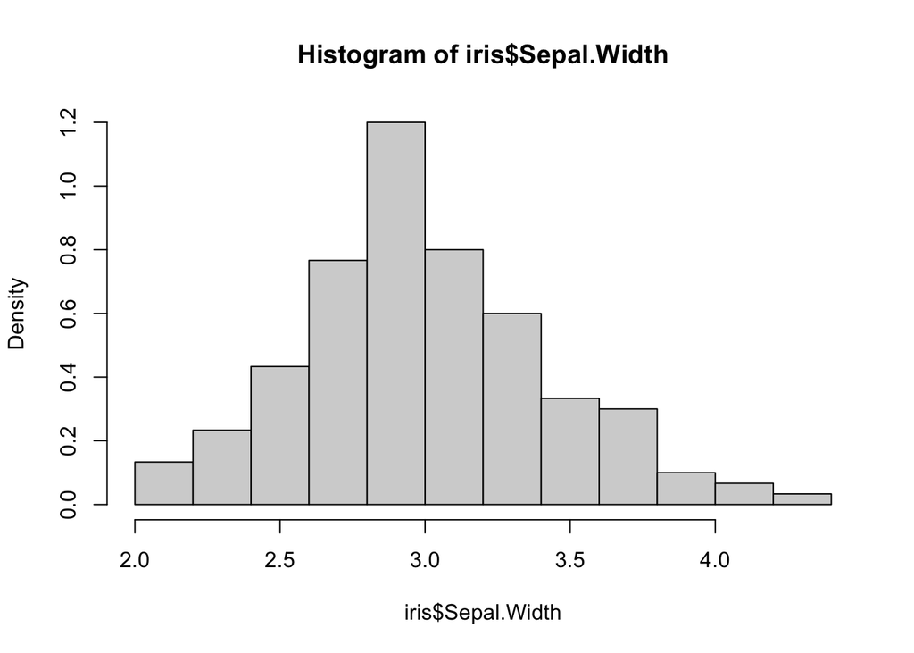

Create a new data frame with the first 100 rows of “iris”. This way, only the first two species, Setosa and Versicolor, are included.

```r
setosa.versicolor <- data.frame(iris[1:100,])
```

Use R’s built-in t-test function to test Sepal.Width between Species.

```r
t.test(Sepal.Width ~ Species, data = setosa.versicolor)
```

```
##
##  Welch Two Sample t-test
##
## data:  Sepal.Width by Species
## t = 9.455, df = 94.698, p-value = 2.484e-15
## alternative hypothesis: true difference in means between group setosa and group versicolor is not equal to 0
## 95 percent confidence interval:
##  0.5198348 0.7961652
## sample estimates:
##     mean in group setosa mean in group versicolor
##                    3.428                    2.770
```

Look at the p-value to determine whether to reject or fail to reject the null hypothesis. Since the p-value here is smaller than .05, I will reject the null and conclude with a high degree of confidence that the true difference in mean sepal width between Setosa and Versicolor is not 0.

### Example 2: Versicolor vs Virginica

Create a new data frame with the last 100 rows of “iris”. This way, only the last two species, Versicolor and Virginica, are included.

```r
versicolor.virginica <- data.frame(iris[51:150,])
```

Use R’s built-in t-test function to test Sepal.Width between Species.

```r
t.test(Sepal.Width ~ Species, data = versicolor.virginica)
```

```
##
##  Welch Two Sample t-test
##
## data:  Sepal.Width by Species
## t = -3.2058, df = 97.927, p-value = 0.001819
## alternative hypothesis: true difference in means between group versicolor and group virginica is not equal to 0
## 95 percent confidence interval:
##  -0.33028364 -0.07771636
## sample estimates:
## mean in group versicolor  mean in group virginica
##                    2.770                    2.974
```

Look at the p-value to determine whether to reject or fail to reject the null hypothesis. Since the p-value here is smaller than .05, I will reject the null and conclude with a high degree of confidence that the true difference in mean sepal width between Versicolor and Virginica is not 0.

## One-sample *t*-test

### Example 3: Setosa vs iris population

View the summary of the “iris” dataset to determine the mean sepal width for the iris population. It is 3.057.

```r
summary(iris)
```

```
##   Sepal.Length    Sepal.Width     Petal.Length    Petal.Width
##  Min.   :4.300   Min.   :2.000   Min.   :1.000   Min.   :0.100
##  1st Qu.:5.100   1st Qu.:2.800   1st Qu.:1.600   1st Qu.:0.300
##  Median :5.800   Median :3.000   Median :4.350   Median :1.300
##  Mean   :5.843   Mean   :3.057   Mean   :3.758   Mean   :1.199
##  3rd Qu.:6.400   3rd Qu.:3.300   3rd Qu.:5.100   3rd Qu.:1.800
##  Max.   :7.900   Max.   :4.400   Max.   :6.900   Max.   :2.500
##        Species
##  setosa    :50
##  versicolor:50
##  virginica :50
##
##
##
```

Create a new data frame with only the first 50 rows of “iris”. This way, only Setosa is included.

```r
setosa <- data.frame(iris[1:50,])
```

Use R’s built-in t-test function to test Sepal.Width vs the iris population mean of 3.057.

```r
t.test(setosa$Sepal.Width, mu=3.057)
```

```
##
##  One Sample t-test
##
## data:  setosa$Sepal.Width
## t = 6.9206, df = 49, p-value = 8.804e-09
## alternative hypothesis: true mean is not equal to 3.057
## 95 percent confidence interval:
##  3.320271 3.535729
## sample estimates:
## mean of x
##     3.428
```

Look at the p-value to determine whether to reject or fail to reject the null hypothesis. Since the p-value here is smaller than .05, I will reject the null and conclude with a high degree of confidence that the Setosa mean sepal width is not equal to the iris population mean sepal width.